# Reexplorando PROPERATI

Trabajos Practicos - Laboratorio de Datos

# Este notebook

En este notebook el objetivo es que ustedes puedan emplear lo visto en el notebook *Nociones básicas de estadística descriptiva* para caracterizar y repensar el dataset de propiedades de `ar_properties.csv`.

Proponemos una serie de preguntas *guía* a responder usando las herramientas presentadas en el notebook de estadística descriptiva. En todas la preguntas propuestas, el objetivo es que identifiquen alguna medida o visualización que les ayude a responder la pregunta *conceptual* realizada. Esto significa que todo gráfico o número debería ir acompañado de una interpretación del significado que ustedes asignen al mismo.

# El dataset

El dataset que usaremos pueden encontrarlo en la página de la materia (`ar_properties.csv`). En caso de que existan dudas sobre como cargarlo, el notebook de estadística descriptiva (y los videos asociados) describen como hacerlo.

# Preguntas: Primera parte

Construya un subset de los datos totales filtrando propiedades de Capital Federal, tipo de operación Venta y moneda en dólares.

** Empecemos **

Leamos primero el dataSet:

```r
# Leo el archivo
datos <- read.csv('ar_properties.csv')
# visualizo solo una parte pequeña de los datos
head(datos)
```

```
##                         id   ad_type start_date   end_date created_on       lat
## 1 S0we3z3V2JpHUJreqQ2t/w== Propiedad 2019-04-14 2019-06-14 2019-04-14 -34.94331
## 2 kMxcmAS8NvrynGBVbMOEaQ== Propiedad 2019-04-14 2019-04-16 2019-04-14 -34.63181
## 3 Ce3ojF+ZTOkB8d+LI9dpxg== Propiedad 2019-04-14 9999-12-31 2019-04-14        NA
## 4 AUGpj3raGmOCiulSMGIBPA== Propiedad 2019-04-14 9999-12-31 2019-04-14 -34.65471
## 5 m+MwZmJl3OoxmfWcB//sBA== Propiedad 2019-04-14 2019-07-09 2019-04-14 -34.65495
## 6 pJRPrB5G8JlK9J3Yg5F+Hg== Propiedad 2019-04-14 2019-08-08 2019-04-14 -32.93547
##         lon        l1                       l2             l3     l4   l5 l6
## 1 -54.92966   Uruguay                Maldonado Punta del Este   <NA> <NA> NA
## 2 -58.42060 Argentina          Capital Federal          Boedo   <NA> <NA> NA
## 3        NA Argentina Bs.As. G.B.A. Zona Norte           <NA>   <NA> <NA> NA
## 4 -58.79089 Argentina Bs.As. G.B.A. Zona Oeste         Moreno Moreno <NA> NA
## 5 -58.78712 Argentina Bs.As. G.B.A. Zona Oeste         Moreno Moreno <NA> NA
## 6 -60.68398 Argentina                 Santa Fe        Rosario   <NA> <NA> NA
##   rooms bedrooms bathrooms surface_total surface_covered price currency
```

[output cut: 20 more lines]

```r
# Analizo los nombres de las columnas del archivo
print(colnames(datos))
```

```
##  [1] "id"              "ad_type"         "start_date"      "end_date"
##  [5] "created_on"      "lat"             "lon"             "l1"
##  [9] "l2"              "l3"              "l4"              "l5"
## [13] "l6"              "rooms"           "bedrooms"        "bathrooms"
## [17] "surface_total"   "surface_covered" "price"           "currency"
## [21] "price_period"    "title"           "property_type"   "operation_type"
```

```r
# filtros que queremos
pais      <- is.element(datos$l1,"Argentina")
region    <- is.element(datos$l2,"Capital Federal")
moneda    <- is.element(datos$currency,"USD")
operacion <- is.element(datos$operation_type,"Venta")

# los demas sin los na
propiedad    <- !is.na(datos$property_type)
lat          <- !is.na(datos$lat)
lon          <- !is.na(datos$lon)
price        <- !is.na(datos$price)
sup_total    <- !is.na(datos$surface_total)
sup_cubierta <- !is.na(datos$surface_covered)
barrio       <- !is.na(datos$l3)

# condicion multiple
# vector logico con TRUEs en los registros seleccionados
new_vec <- (pais  & region & moneda       & propiedad & operacion & lat
            & lon & price  & sup_cubierta & sup_total & barrio)

# nueva base
new_df <- datos[new_vec,c(3,4,10,17,19,23)]
```

```r
# Imprimimos la cabeza de el nuevo datset
head(new_df)
```

```
##     start_date   end_date               l3 surface_total   price property_type
## 252 2019-04-14 2019-04-29 Parque Patricios          3586 2600000     DepÃ³sito
## 255 2019-04-14 2019-07-10         Barracas           300  320000            PH
## 263 2019-04-14 2019-04-15            Boedo           178  500000          Casa
## 271 2019-04-14 2019-06-30          Palermo           240  350000          Casa
## 276 2019-04-14 2019-05-21        Versalles           140  155000          Casa
## 289 2019-04-14 9999-12-31  Velez Sarsfield            95  199900          Casa
```

## ¿Es el precio por metro cuadrado igual en toda el dataset? ¿Cómo varía?

*Cree precio por metro cuadrado (precio por m2). Caracterice esta variable usando las herramientas de estadística descriptiva vistas.*

**Solucion:**

```r
new_df$preciom2 <- new_df$price / new_df$surface_total
preciom2 <- new_df$preciom2

summary(preciom2)
```

```
##      Min.   1st Qu.    Median      Mean   3rd Qu.      Max.
##      0.74   2000.00   2553.57   2702.74   3142.86 240000.00
```

Se puede ver claramente entre los Cuartiles que los precios por metro cuadrado no es igual. Además, tenemos un minimo de $0,74$ y un maximo de $240000$.

Nos podriamos preguntar que lleva a esta variacion. Por otro lado, ¿Como es que una propiedad puede valer $240000$ por $m^2$?¿Porqué sucede esto?¿Hay algo malo en el dataset para que esto pase?

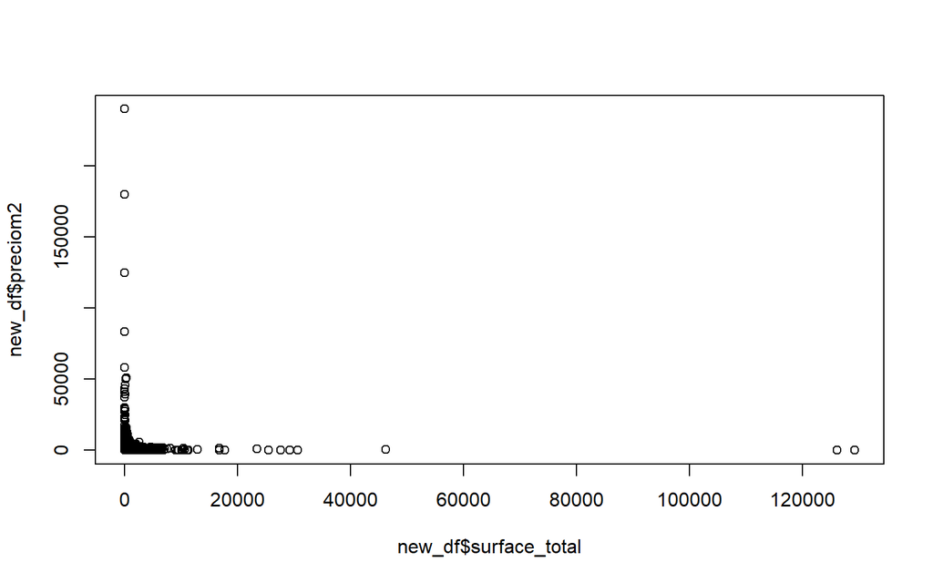

```r
plot(new_df$surface_total, new_df$preciom2)
```

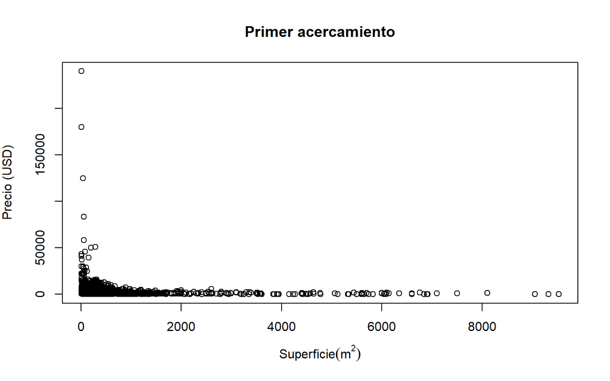

```r
filtroPt1  <- new_df$surface_total < 10000
filtroPt2  <- new_df$surface_total<5000 & new_df$preciom2<5000
filtroPt3 <- new_df$surface_total<1000 & new_df$preciom2<5000
filtroPt4 <- new_df$surface_total<700 & new_df$preciom2<2000


plot(new_df$surface_total[filtroPt1], new_df$preciom2[filtroPt1],
     xlab=expression('Superficie' (m^2)), ylab=expression('Precio (USD)'),
     main="Primer acercamiento")
```

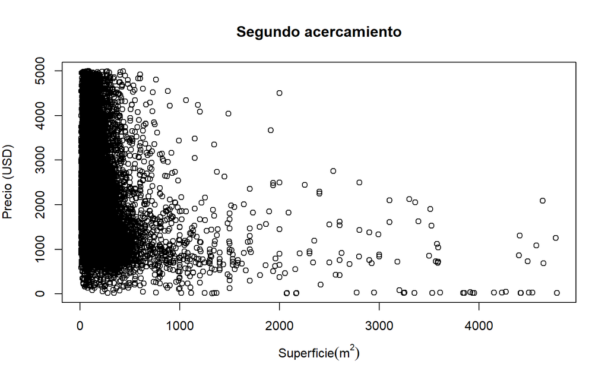

```r
plot(new_df$surface_total[filtroPt2], new_df$preciom2[filtroPt2],
     xlab=expression('Superficie' (m^2)), ylab=expression('Precio (USD)'),
     main="Segundo acercamiento")
```

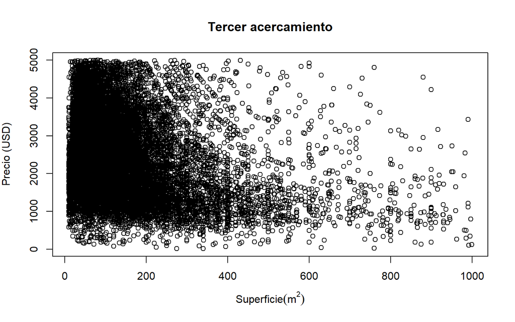

```r
plot(new_df$surface_total[filtroPt3], new_df$preciom2[filtroPt3],
     xlab=expression('Superficie' (m^2)), ylab=expression('Precio (USD)'),
     main="Tercer acercamiento")
```

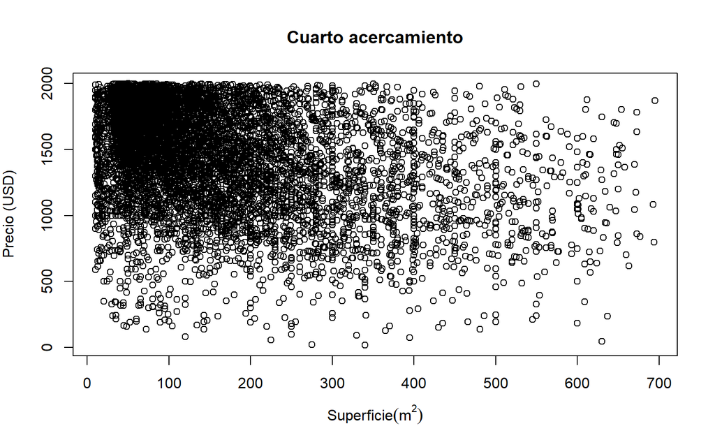

```r
plot(new_df$surface_total[filtroPt4], new_df$preciom2[filtroPt4],
     xlab=expression('Superficie' (m^2)), ylab=expression('Precio (USD)'),
     main="Cuarto acercamiento")
```

Acá solo podemos ver como se aglomeran los puntos al rededor del promedio dado. Pero no es una forma muy amena de entender que esta pasando.

Lo que si es seguro, es que el precio por metro cuadrado no es igual en todo el dataset.

A modo de histograma, podemos visualizar mejor que pasa.

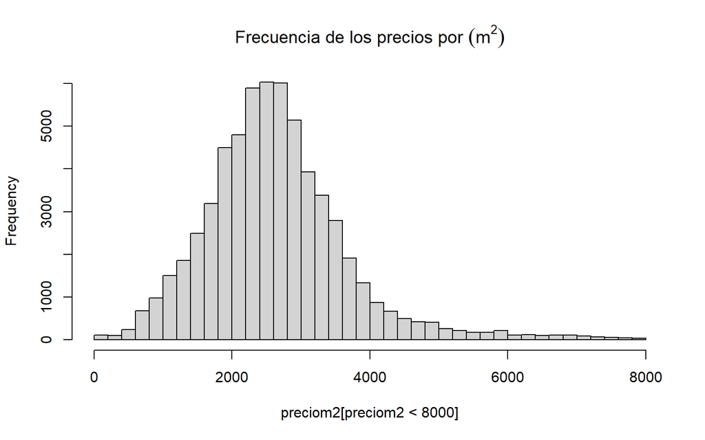

```r
hist(preciom2[preciom2<8000], 50, main=expression('Frecuencia de los precios por ' (m^2)))
```

Histogramiemos que pasa con las superficies.

```r
summary(new_df$surface_total)
```

```
##     Min.  1st Qu.   Median     Mean  3rd Qu.     Max.
##     10.0     45.0     68.0    132.6    118.0 129189.0
```

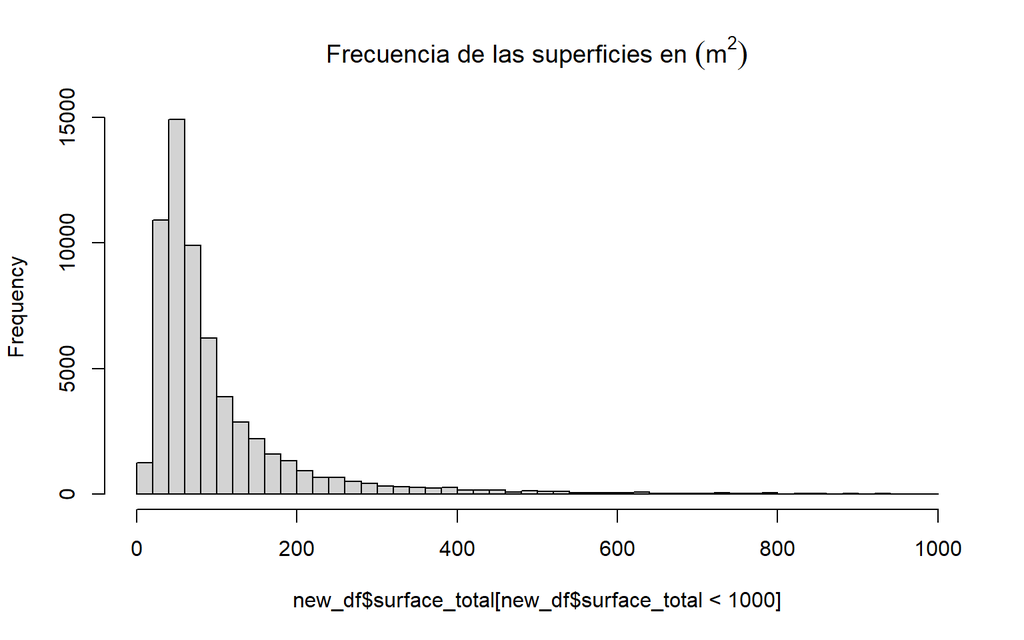

```r
hist(new_df$surface_total[new_df$surface_total<1000], 50, main=expression('Frecuencia de las superficies en ' (m^2)))
```

Acá, podemos ver que hay una variación enorme con respecto a los datos de las superficies totales. Sin embargo, la media respecto de las superficies es de $\sim 132 m^2$. Teniendo en cuenta que el precio promedio es de

```r
summary(new_df$price)
```

```
##     Min.  1st Qu.   Median     Mean  3rd Qu.     Max.
##     5900   115000   170000   276672   285000 26500000
```

Y para el precio por metro cuadrado es de:

```r
summary(new_df$preciom2)
```

```
##      Min.   1st Qu.    Median      Mean   3rd Qu.      Max.
##      0.74   2000.00   2553.57   2702.74   3142.86 240000.00
```

```r
aprox <- 132 * 2702.74
print(aprox)
```

```
## [1] 356761.7
```

Notemos que lo que hicimos acá es ver si, a partir de definir un valor medio para el $m^2$ podiamos calcular el precio estimado por la media para una propiedad (de indistinta clasificación) de unos $132 m^2$ totales, lo que es la media de las propiedades totales.

```r
print(276672/356761.1)
```

```
## [1] 0.7755106
```

## ¿Cuales propiedades son caras, promedio o baratas?

*Construya una partición que separe el precio por metro cuadrado en tres categorías.*

En particular esta pregunta es bastante etraña. En particular nos piden decidir que propiedades son mas caras, cuales mas baratas y cuales rondan un valor medio.

En particular podemos partir de las siguientes divisiones:

- Separarla por cuartiles.
- Ver como varia el promedio respecto de su desviación standard.
1. **CUARTILES**

```r
#BARATAS

baratas_cuar = table(new_df[preciom2 < 2000,]$property_type)
prop.table(baratas_cuar)
```

```
##
##            Casa         Cochera       DepÃ³sito    Departamento Local comercial
##      0.14232185      0.04049435      0.02294241      0.39659479      0.06744675
##            Lote         Oficina            Otro              PH
##      0.01761767      0.09722587      0.02655798      0.18879832
```

```r
# MEDIOS
medio_cuar = table(new_df[preciom2 > 2000 & preciom2 < 3142,]$property_type)
prop.table(medio_cuar)
```

```
##
##            Casa         Cochera       DepÃ³sito    Departamento Local comercial
##    0.0217164471    0.0078257467    0.0001630364    0.8418220947    0.0235424547
##            Lote         Oficina            Otro              PH
##    0.0033911569    0.0322812052    0.0023477240    0.0669101343
```

```r
# ALTOS
altos_cuar = table(new_df[preciom2 >3142,]$property_type)
prop.table(altos_cuar)
```

```
##
##            Casa         Cochera       DepÃ³sito    Departamento Local comercial
##    1.264360e-02    1.283615e-03    6.418073e-05    8.921122e-01    5.108786e-02
##            Lote         Oficina            Otro              PH
##    5.968808e-03    2.259162e-02    1.347795e-03    1.290033e-02
```

La segunda forma seria: (promedio-sd, promedio+sd) —->> promedio

```r
# Tomo los valores del promedio y la desviación standar
promedio <- mean(as.integer(new_df$preciom2))
sd <- sd(as.integer(preciom2))

pm2 <- new_df$preciom2
prom_men_sd <- promedio - sd
prom_mas_sd <- promedio + sd

sd_menos = table(new_df[pm2 <= prom_men_sd,]$property_type)
p_prom   = table(new_df[(pm2 > prom_men_sd) & (pm2 < prom_mas_sd),]$property_type)
sd_mas   = table(new_df[new_df$preciom2 <= (promedio + sd),]$property_type)

print("------------------------------------------")
```

```
## [1] "------------------------------------------"
```

```r
cat("\t", "Promedio: ", promedio, "\n")
```

```
##   Promedio:  2702.316
```

```r
cat("\t", "Desviación standard: ", sd, "\n")
```

```
##   Desviación standard:  1998.575
```

```r
print("------------------------------------------")
```

```
## [1] "------------------------------------------"
```

```r
print("------------------------------------------")
```

```
## [1] "------------------------------------------"
```

```r
cat("\n", "\t","Promedio - sd", "\n")
```

```
##
##       Promedio - sd
```

```r
prop.table(sd_menos)
```

```
##
##            Casa         Cochera       DepÃ³sito    Departamento Local comercial
##      0.25162973      0.02868318      0.04693611      0.12125163      0.14080834
##            Lote         Oficina            Otro              PH
##      0.06649283      0.06910039      0.18122555      0.09387223
```

```r
print("------------------------------------------")
```

```
## [1] "------------------------------------------"
```

```r
cat("\n","\t", " +/- Promedio","\n")
```

```
##
##        +/- Promedio
```

```r
prop.table(p_prom)
```

```
##
##            Casa         Cochera       DepÃ³sito    Departamento Local comercial
##     0.047781511     0.014932794     0.005469071     0.748336991     0.036517624
##            Lote         Oficina            Otro              PH
##     0.006360582     0.047215745     0.006120560     0.087265121
```

```r
print("------------------------------------------")
```

```
## [1] "------------------------------------------"
```

```r
cat("\n","\t", "Promedio + sd","\n")
```

[output not shown]

```r
prop.table(sd_mas)
```

```
##
##            Casa         Cochera       DepÃ³sito    Departamento Local comercial
##     0.050427278     0.015111262     0.006007276     0.740197986     0.037871224
##            Lote         Oficina            Otro              PH
##     0.007141044     0.047499788     0.008393265     0.087350876
```

```r
print("------------------------------------------")
```

```
## [1] "------------------------------------------"
```

[output not shown]

- ¿Qué considera que describe mejor el precio de una propiedad, su número de habitaciones (*rooms*) o su superficie cubierta?
- ¿Cómo cambia la superficie cubierta por número de habitaciones (*rooms*) en el dataset?¿Cambia al considerar distintos tipos de propiedad?¿Y distintos barrios? *Caracterice metro cuadrado por habitación. Caracterice esta variable usando las herramientas de estadística descriptiva vistas.*
- ¿Cuál es la relación entre la superficie total y la superficie cubierta, al considerar distintos tipos de propiedades?
- ¿Cómo se relaciona la cantidad de habitaciones (*rooms*) con la cantidad de baños (*bathrooms*)?¿Cómo cambia según el tipo de propiedad?¿Y según el barrio?
- ¿Cuánto tiempo duran los anuncios en departamentos en CABA? ¿Nota algo extraño? *Para calcular la cantidad de días entre dos fechas, puede restarlas si están en formato `Date`.*
- ¿Cómo cambia la cantidad de anuncios publicados en los distintos días de la semana? *La función `weekdays` permite identificar a qué día corresponde el anuncio publicado.*

# Preguntas: Segunda parte

Amplíe el dataset para considerar todas las propiedades de argentina, con tipo de operación Venta o Alquiler (y cualquier moneda).

- ¿Cuál es la relación entre región (`l2`) y tipo de operación (Venta o Alquiler)? ¿Cambia con el tipo de propiedad?
- ¿Qué diferencia existe en el tipo de operación (Venta o Alquiler) entre Catamarca y La Rioja? ¿Y entre Chaco y Santa Cruz?
- ¿Cómo describiría la relación entre la variable `l2` (región) y `l3` (barrio)? ¿Están igual de particionadas todas las regiones? *Construya una lista con tantos elementos cómo regiones (categorías de `l2`) y en cada elemento incluye las subregiones asociadas (categorías de `l3`). Construya un vector representando la cantidad de subregiones para cada región y resuma este vector.*
- Caracterice el *fondo* de las propiedades (superficie total - superficie cubierta) para distintas regiones del país. ¿En qué lugar los *fondos* son más grandes? ¿Cambia según el tipo de propiedad?